# LuthraSauravPS4B

Saurav Luthra

2025-03-30

# SAURAV LUTHRA, MTH643 PROBLEM SET 4B

## =========== OVERVIEW ===========

**HP :** Helmerich & Payne, Inc. (NYSE)

**PDS :** Precision Drilling Corporation (NYSE)

## =========== SETUP ===========

```r
# ==============================================================================
# GET DATA AND SETUP FOR HP

getSymbols("HP", src = "yahoo", from = as.Date("2020-02-01", to = as.Date("2025-02-01")))
```

```
## [1] "HP"
```

```r
HP_prices <- (HP$HP.Adjusted)

HP_log_returns <- as.vector(diff(log(HP_prices))[-1])

# ==============================================================================
# GET DATA AND SETUP FOR PDS

getSymbols("PDS", src = "yahoo", from = as.Date("2020-02-01", to = as.Date("2025-02-01")))
```

```
## [1] "PDS"
```

```r
PDS_prices <- (PDS$PDS.Adjusted)

PDS_log_returns <- as.vector(diff(log(PDS_prices))[-1])
```

## =========== QUESTION 4 ===========

#### [**T-Copula of HP Log Returns and PDS Log Returns**]

Using both methods of making the data uniform-transformed, we fit 2 T-copulas to the bivariate data, using maximum likelihood estimation (MLE). The results of both fitted copulas are relatively similar and have very close degrees of freedom and correlation estimates. The results are the following:

**FT1:**

**Estimated Correlation:** 0.6762, **SE:** 0.0162

**Estimated Tail Parameter Index (DoF):** 3.9374, **SE:** 0.5333

**FT2:**

**Estimated Correlation:** 0.6769, **SE:** 0.0163

**Estimated Tail Parameter Index (DoF):** 3.7966, **SE:** 0.5128

Uniform transformation **(data1)** (using methods like pstd) assumes a specific distribution for the data (e.g., student T-distribution) and transforms it into uniform marginals while preserving distributional characteristics like heavy tails. This is useful for modeling extreme events but requires correct specification of the marginal distribution. Rank-based transformation **(data2)**, on the other hand, ranks the data and scales it to uniform values without assuming any distribution, making it more flexible but potentially less accurate for data with specific tail behaviors. While rank-based methods are robust and non-parametric, uniform transformation can provide better modeling for data with known distributional characteristics. Applying pstd to **HP_log_returns** and **PDS_log_returns** would transform these datasets into uniform marginals by assuming that the log returns follow a student T-distribution. This transformation would preserve the heavy-tail characteristics typically found in stock log-return data, which is particularly useful when modeling extreme events or volatility clustering. After applying pstd, both **HP_log_returns** and **PDS_log_returns** would be mapped to the interval [0, 1], allowing for copula modeling to focus on their dependence structure while accounting for the distributional characteristics of the returns.

```r
# ==============================================================================
# SETUP

n <- length(HP_log_returns)

cor_tau = cor(HP_log_returns, PDS_log_returns, method="kendall")
omega = sin(pi * cor_tau / 2)
cop_t_dim2 = tCopula(omega, dim=2, dispstr="un", df=4)

# ==============================================================================
# UNIVARIATE T-DISTRIBUTIONS FROM QUESTION 2

est_HP = as.numeric(fitdistr(HP_log_returns, "t")$estimate)
std_HP <- est_HP[2] * sqrt(est_HP[3] / (est_HP[3] - 2))

est_PDS = as.numeric(fitdistr(PDS_log_returns, "t")$estimate)
std_PDS <- est_PDS[2] * sqrt(est_PDS[3] / (est_PDS[3] - 2))

# ==============================================================================
# UNIFORM-TRANSFORMED DATA

data1 = cbind(pstd(HP_log_returns, est_HP[1], std_HP, est_HP[3]), pstd(PDS_log_returns, est_PDS[1], std_PDS, est_PDS[3]))
data2 = cbind(rank(HP_log_returns)/(n+1), rank(PDS_log_returns)/(n+1))

# ==============================================================================
# FIT T-COPULAS

ft1 = fitCopula(cop_t_dim2, data1, method="ml", start=c(omega,4))
ft2 = fitCopula(cop_t_dim2, data2, method="ml", start=c(omega,4))

# ==============================================================================
# OUTPUT ESTIMATES FT1

# parameter estimates
estimates_ft1 <- coef(ft1)
# standard errors
std_errors_ft1 <- sqrt(diag(vcov(ft1)))

cat("FT1: \n\n")
```

```
## FT1:
```

```r
cat("Estimated Correlation:", estimates_ft1[1], "\n")
```

```
## Estimated Correlation: 0.6761688
```

```r
cat("Standard Error (Correlation):", std_errors_ft1[1], "\n")
```

```
## Standard Error (Correlation): 0.01623498
```

```r
cat("Estimated Tail Parameter Index (DoF):", estimates_ft1[2], "\n")
```

```
## Estimated Tail Parameter Index (DoF): 3.937491
```

```r
cat("Standard Error (Degrees of Freedom):", std_errors_ft1[2], "\n")
```

```
## Standard Error (Degrees of Freedom): 0.5332915
```

```r
# ==============================================================================
# OUTPUT ESTIMATES FT2

# parameter estimates
estimates_ft2 <- coef(ft2)
# standard errors
std_errors_ft2 <- sqrt(diag(vcov(ft2)))

cat("\n\nFT2: \n\n")
```

```
##
##
## FT2:
```

```r
cat("Estimated Correlation:", estimates_ft2[1], "\n")
```

```
## Estimated Correlation: 0.6768862
```

```r
cat("Standard Error (Correlation):", std_errors_ft2[1], "\n")
```

```
## Standard Error (Correlation): 0.01634241
```

```r
cat("Estimated Tail Parameter Index (DoF):", estimates_ft2[2], "\n")
```

```
## Estimated Tail Parameter Index (DoF): 3.796616
```

```r
cat("Standard Error (Degrees of Freedom):", std_errors_ft2[2], "\n")
```

```
## Standard Error (Degrees of Freedom): 0.5128303
```

## =========== QUESTION 5 ===========

#### [**Maximum Likelihood Estimates of Gaussian, Clayton, and Joe Copulas of HP and PDS Log-Returns**]

For the pair (HP_log_returns, PDS_log_returns) we use the maximum likelihood method to fit a Gaussian, Clayton, and Joe copula to model the underlying pairs of log returns.

**Normal Copula**

Correlation (ρ): Estimate = 0.6559, SE = 0.0132

**Clayton Copula**

Dependence parameter (θ): Estimate = 1.8243, SE = 0.0731

**Joe Copula**

Dependence parameter (θ): Estimate = 1.9975, SE = 0.0567

The **Gaussian copula’s** moderate correlation of 0.6559 suggests a significant but not extreme linear relationship between the two stocks, reflecting a typical market behavior where they are somewhat correlated but not perfectly synchronized. This might indicate that while both stocks share common industry risks, their returns are influenced by company-specific factors, and extreme co-movements are better captured by copulas like Clayton or Joe. The strong tail dependence observed in both the **Clayton and Joe copulas** suggests that extreme movements in one stock are likely to be associated with extreme movements in the other, particularly in the upper and lower tails. Given that both stocks belong to the same country (USA) and industry (oil production), this is not surprising. The oil sector is highly sensitive to macroeconomic factors and oil prices, which often drive sharp, correlated movements in the stock prices of companies within the industry. For example, a significant drop in oil prices or a major economic event could simultaneously impact both stocks, leading to joint extreme negative returns, while positive economic shifts or surges in oil prices might drive strong positive returns in both. This tight linkage between the stocks’ returns is indicative of the broader systemic and macroeconomic factors influencing their performance, and has been highlighted in the past few problem sets also.

The **standard errors (SE)** of the estimated parameters for each copula model are relatively small, indicating that the parameter estimates for the correlation (Gaussian copula) and dependence parameters (Clayton and Joe copulas) are statistically significant and have been estimated with a good degree of precision.

```r
# ==============================================================================
# FIT THE GAUSSIAN, CLAYTON, AND JOE COPULAS

fnorm = fitCopula(copula=normalCopula(dim=2), data=data1, method="ml")

fclayton = fitCopula(copula=claytonCopula(1,dim=2),data=data1, method="ml")

fjoe = fitCopula(copula=joeCopula(2,dim=2),data=data1,method="ml")

# ==============================================================================
# OUTPUT ALL ESTIMATED PARAMETERS AND STANDARD ERRORS

# print results for Normal Copula
cat("\n------------------------------\n")
cat("Normal Copula\n")
```

```
## Normal Copula
```

```r
cat("------------------------------\n")
cat(sprintf("Parameter: Estimate = %.4f, SE = %.4f\n", coef(fnorm), sqrt(diag(vcov(fnorm)))))
```

```
## Parameter: Estimate = 0.6559, SE = 0.0132
```

```r
# print results for Clayton Copula
cat("\n------------------------------\n")
cat("Clayton Copula\n")
```

```
## Clayton Copula
```

```r
cat("------------------------------\n")
cat(sprintf("Parameter: Estimate = %.4f, SE = %.4f\n", coef(fclayton), sqrt(diag(vcov(fclayton)))))
```

```
## Parameter: Estimate = 1.8243, SE = 0.0731
```

```r
# print results for Joe Copula
cat("\n------------------------------\n")
cat("Joe Copula\n")
```

```
## Joe Copula
```

```r
cat("------------------------------\n")
cat(sprintf("Parameter: Estimate = %.4f, SE = %.4f\n", coef(fjoe), sqrt(diag(vcov(fjoe)))))
```

```
## Parameter: Estimate = 1.9975, SE = 0.0567
```

## =========== QUESTION 6 ===========

#### [**Copula Diagrams - T, Gaussian, Clayton, Joe**]

Using the ‘contour’ command we create a diagram of all the copulas (T, Gaussian, Clayton, Joe).

Each diagram is a cumulative distribution function (CDF) for the particular bivariate uniform distribution.

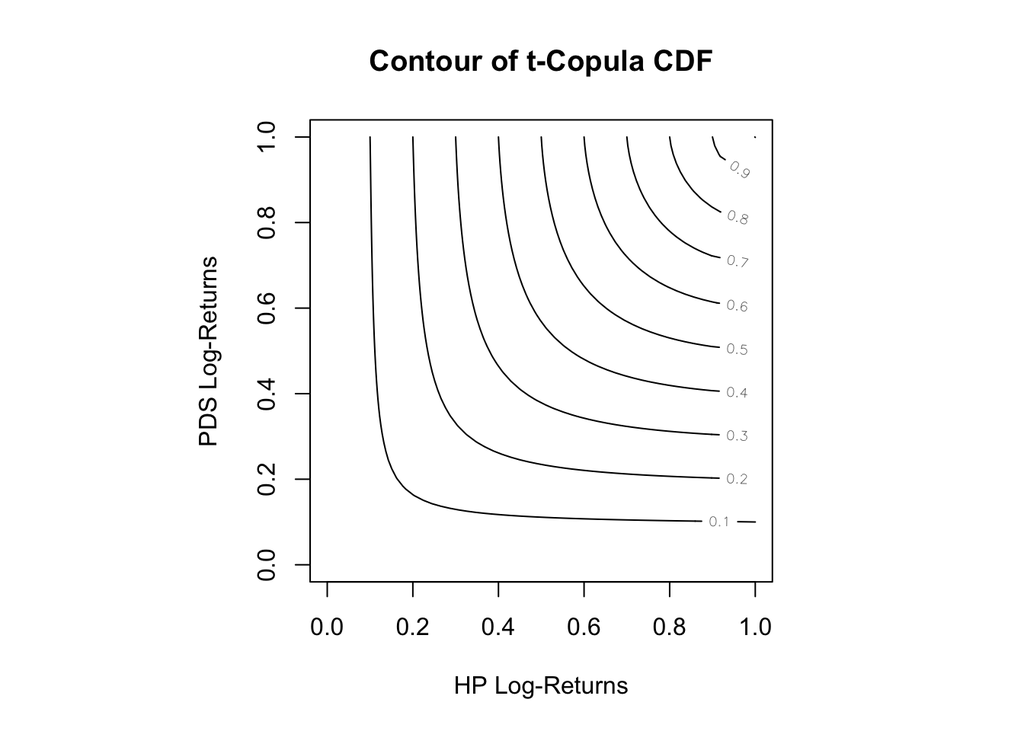

```r
# ==============================================================================
# SETUP

# define a grid of (u,v) values
u_vals = seq(0, 1, length.out = 50)  # 50 points from 0 to 1
v_vals = seq(0, 1, length.out = 50)

# create a meshgrid of all (u,v) pairs
grid = expand.grid(u_vals, v_vals)
colnames(grid) = c("u", "v")

nr = length(u_vals)
nc = length(v_vals)
# ==============================================================================
# T COPULA DIAGRAM

# round the degree of freedom to the nearest integer
ft2@copula@parameters[2] <- round(ft2@copula@parameters[2])

cdf_vals_t = pCopula(as.matrix(grid), copula = ft2@copula)
cdf_matrix_t = matrix(cdf_vals_t, nrow = nr, ncol = nc)
par(pty = "s")
contour(u_vals, v_vals, cdf_matrix_t, xlab="HP Log-Returns", ylab="PDS Log-Returns", main="Contour of t-Copula CDF")
```

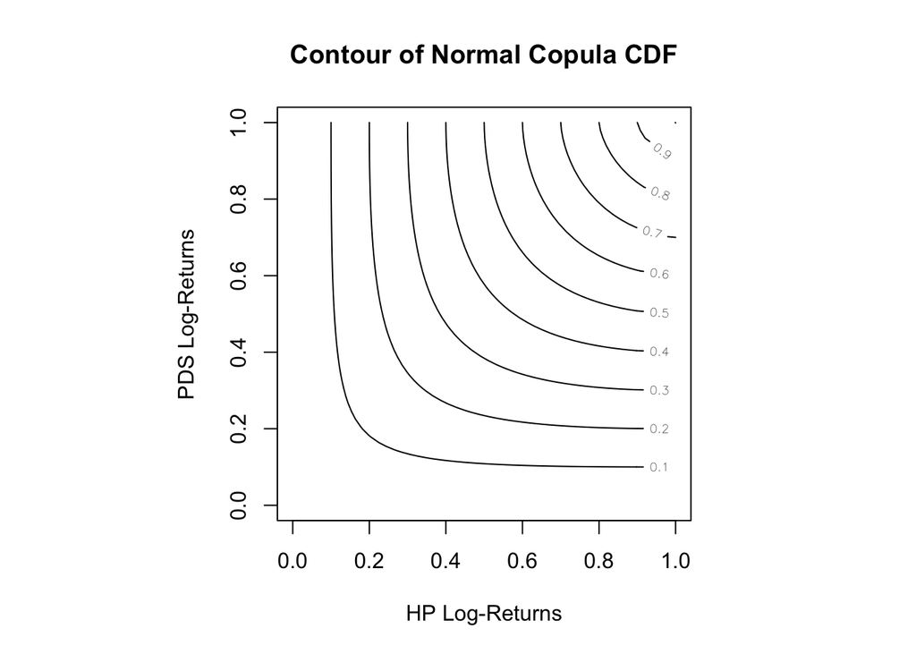

```r
# ==============================================================================
# GAUSSIAN (NORMAL) COPULA DIAGRAM

cdf_vals_norm = pCopula(as.matrix(grid), copula = fnorm@copula)
cdf_matrix_norm = matrix(cdf_vals_norm, nrow = nr, ncol = nc)
par(pty = "s")
contour(u_vals, v_vals, cdf_matrix_norm, xlab="HP Log-Returns", ylab="PDS Log-Returns", main="Contour of Normal Copula CDF")
```

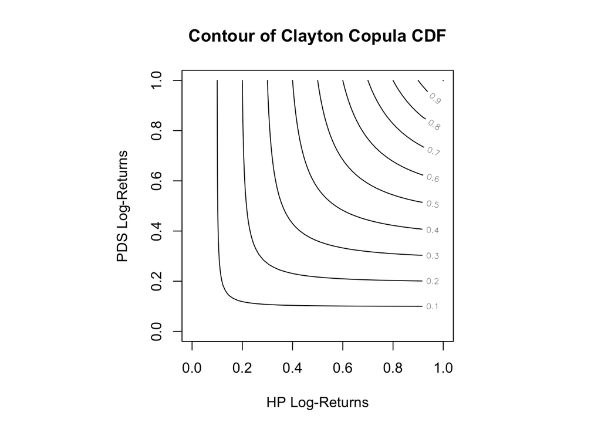

```r
# ==============================================================================
# CLAYTON COPULA DIAGRAM

cdf_vals_clayton = pCopula(as.matrix(grid), copula = fclayton@copula)
cdf_matrix_clayton = matrix(cdf_vals_clayton, nrow = nr, ncol = nc)
par(pty = "s")
contour(u_vals, v_vals, cdf_matrix_clayton, xlab="HP Log-Returns", ylab="PDS Log-Returns", main="Contour of Clayton Copula CDF")
```

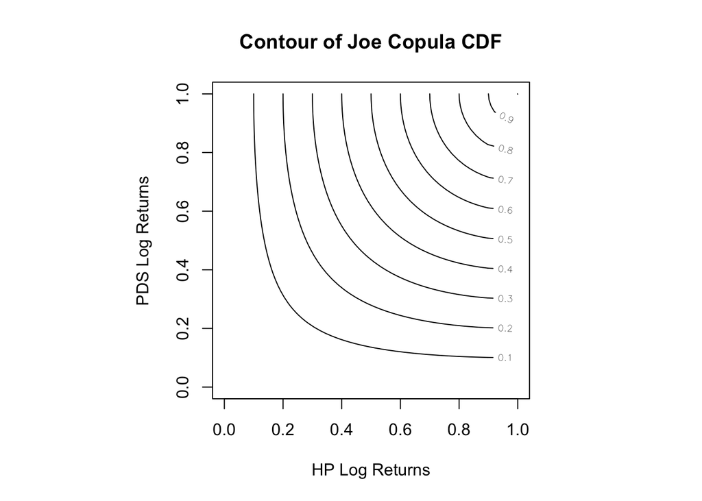

```r
# ==============================================================================
# JOE COPULA DIAGRAM

cdf_vals_joe = pCopula(as.matrix(grid), copula = fjoe@copula)
cdf_matrix_joe = matrix(cdf_vals_joe, nrow = nr, ncol = nc)
par(pty = "s")
contour(u_vals, v_vals, cdf_matrix_joe, xlab="HP Log Returns", ylab="PDS Log Returns", main="Contour of Joe Copula CDF")
```